# `prospect` demo

Jacob Deppen, DigAR Lab, 26 April 2019

## Overview

Simulated surveys are made of four building blocks, some of which have their own building blocks.

1. `Area`: spatial extent
2. `Assemblage`: artifacts/features
   - Made up of multiple `Layer` objects
     - A `Layer` is composed of `Feature` objects
3. `Coverage`: survey strategy
   - Made up of multiple `SurveyUnit` objects
4. `Team`: people
   - Made up of multiple `Surveyor` objects

## Import Python packages

```python
%matplotlib inline
import prospect as pspt
from prospect.utils import beta, truncnorm

import matplotlib.pyplot as plt

import geopandas as gpd
import numpy as np
```

## Create two `Survey` objects

`transect_survey` where the units are transects

`radial_survey` where the units are circular patches like the LEIA Project survey

```python
transect_survey = pspt.Survey(name='transect_survey')
radial_survey = pspt.Survey(name='radial_survey')
```

## Create `Area` from shapefile

```python
shapefile_path = '../tests/test_data/shapefiles/areas/leiap_field1.shp'
area_from_shp = pspt.Area.from_shapefile(
    name='area_from_shp',
    survey_name='deprecated',
    path=shapefile_path,
    vis=beta(a=9, b=1)
)
```

Also available:

- Create from any `shapely` shape
- Create a square `Area` by specifying the desired area value

## Explore `area_from_shp`

```python
area_from_shp.__dict__
```

```
{'_sa_instance_state': <sqlalchemy.orm.state.InstanceState at 0x11ae1b438>,
 'name': 'area_from_shp',
 'survey_name': 'deprecated',
 'shape': <shapely.geometry.polygon.Polygon at 0x11ae23208>,
 'vis': <scipy.stats._distn_infrastructure.rv_frozen at 0x11ae1b0b8>,
 'df':             name survey_name  \
 0  area_from_shp  deprecated

                                                shape  \
 0  POLYGON ((533545.664 4388841.881, 533546.214 4...

                                                  vis
 0  <scipy.stats._distn_infrastructure.rv_frozen o...  }
```

```python
area_from_shp.df
```

|  | name | survey_name | shape | vis |
| --- | --- | --- | --- | --- |
| 0 | area_from_shp | deprecated | POLYGON ((533545.664 4388841.881, 533546.214 4... | <scipy.stats._distn_infrastructure.rv_frozen o... |

```python
type(area_from_shp.df)
```

```
geopandas.geodataframe.GeoDataFrame
```

## Visualize with generic `geopandas` plot

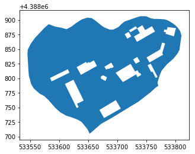

```python
area_from_shp.df.plot();
```

## Create four `Layer` objects

Think of them as four different artifact types (e.g., ceramics, lithics, metal, and bones)

### Layer 1 from a shapefile

```python
layer_shp_path = '../tests/test_data/shapefiles/layers/leiap_field1_points.shp'
layer_from_shp = pspt.Layer.from_shapefile(
    path=layer_shp_path,
    name='ceramics',
    area=area_from_shp,
    assemblage_name='iron_age',
    time_penalty=truncnorm(mean=30, sd=10, lower=5, upper=600),
    ideal_obs_rate=1.0
)
```

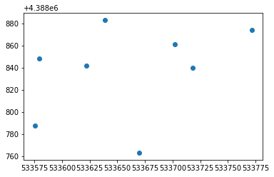

```python
layer_from_shp.df.plot();
```

### Layer 2 from a Poisson point process

```python
poisson_rate = 0.01
layer_from_poisson = pspt.Layer.from_poisson_points(
    rate=poisson_rate,
    name='lithics',
    area=area_from_shp,
    assemblage_name='iron_age',
    time_penalty=truncnorm(mean=30, sd=10, lower=5, upper=600),
    ideal_obs_rate=beta(9.5, 0.5)
)
```

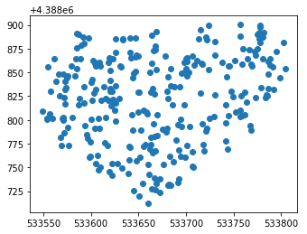

```python
layer_from_poisson.df.plot();
```

### Layer 3 from a Thomas point process

```python
parent_rate = 0.01
child_rate = 0.1
gauss = 10.0
layer_from_thomas = pspt.Layer.from_thomas_points(
    parent_rate=parent_rate,
    child_rate=child_rate,
    gauss_var = gauss,
    name='metals',
    area=area_from_shp,
    assemblage_name='iron_age',
    time_penalty=truncnorm(mean=20, sd=5, lower=2, upper=600),
    ideal_obs_rate=1.0
)
```

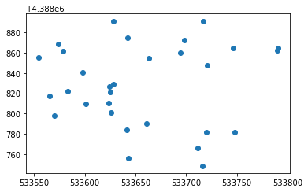

```python
layer_from_thomas.df.plot();
```

### Layer 4 from a Matern point process

```python
parent_rate = 0.01
child_rate = 0.1
radius = 10.0
layer_from_matern = pspt.Layer.from_matern_points(
    parent_rate=parent_rate,
    child_rate=child_rate,
    radius = radius,
    name='bones',
    area=area_from_shp,
    assemblage_name='iron_age',
    time_penalty=truncnorm(mean=30, sd=10, lower=5, upper=600),
    ideal_obs_rate=1.0
)
```

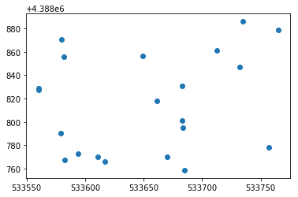

```python
layer_from_matern.df.plot();
```

Can also create `Layer` from:

- a list of `Feature` objects
- pseudorandom point coordinates

## Compile the `Layer` objects into an `Assemblage`

```python
iron_age_assemblage = pspt.Assemblage(
    name='iron_age',
    survey_name='deprecated',
    area_name='area_from_shp',
    layer_list=[layer_from_shp, layer_from_poisson, layer_from_thomas, layer_from_matern]
)
```

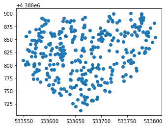

```python
iron_age_assemblage.df.plot();
```

## Build two `Coverage` objects

- One for transects
- One for radial units

## Create transect `Coverage`

```python
coverage_transects = pspt.Coverage.from_transects(
    name='transects',
    area=area_from_shp,
    survey_name='deprecated',
    spacing=10.0,
    sweep_width=2.0,
    orientation=0.0,
    optimize_orient_by='area_coverage', # area_orient aligns w/orient_axis
    orient_increment=4.0,
    orient_axis='short',
    min_time_per_unit=5.0
)
```

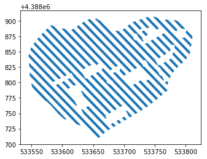

```python
coverage_transects.df.plot();
```

## Create radial `Coverage`

```python
coverage_radials = pspt.Coverage.from_radials(
    name='radials',
    area=area_from_shp,
    survey_name="deprecated",
    spacing=10.0,
    radius=2.0,
    orientation=0.0,
    optimize_orient_by='area_coverage',
    orient_increment=4.0,
    orient_axis='short',
    min_time_per_unit=60
)
```

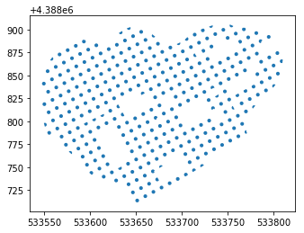

```python
coverage_radials.df.plot();
```

Can also create `Coverage` from:

- shapefile
- `geopandas GeoDataFrame`

## Create six `Surveyor` objects

Best to simply create each person by hand

## Experts

```python
expert = pspt.Surveyor(
    name='expert',
    team_name='leiap_team',
    surveyor_type='expert_person',
    skill=1.0,
    speed_penalty=0.0
)
```

## Mid-level

```python
mid1 = pspt.Surveyor(
    name='mid1',
    team_name='leiap_team',
    surveyor_type='mid_level_person',
    skill=0.9,
    speed_penalty=0.1
)
mid2 = pspt.Surveyor(
    name='mid2',
    team_name='leiap_team',
    surveyor_type='mid_level_person',
    skill=0.8,
    speed_penalty=0.1
)
```

## Novices

```python
novice1 = pspt.Surveyor(
    name='novice1',
    team_name='leiap_team',
    surveyor_type='novice_person',
    skill=0.75,
    speed_penalty=0.2
)
novice2 = pspt.Surveyor(
    name='novice2',
    team_name='leiap_team',
    surveyor_type='novice_person',
    skill=beta(7, 3),
    speed_penalty=0.2
)
novice3 = pspt.Surveyor(
    name='novice3',
    team_name='leiap_team',
    surveyor_type='novice_person',
    skill=0.70,
    speed_penalty=0.25
)
```

## Create `Team` from `Surveyor` objects

```python
team_list = [expert, mid1, mid2, novice1, novice2, novice3]
leiap_team = pspt.Team(
    name='leiap_team',
    survey_name='deprecated',
    surveyor_list=team_list,
    assignment='naive'
)
```

```python
leiap_team.df
```

|  | skill | speed_penalty | surveyor_name | surveyor_type | team_name |
| --- | --- | --- | --- | --- | --- |
| 0 | 1 | 0.00 | expert | expert_person | leiap_team |
| 1 | 0.9 | 0.10 | mid1 | mid_level_person | leiap_team |
| 2 | 0.8 | 0.10 | mid2 | mid_level_person | leiap_team |
| 3 | 0.75 | 0.20 | novice1 | novice_person | leiap_team |
| 4 | <scipy.stats._distn_infrastructure.rv_frozen o... | 0.20 | novice2 | novice_person | leiap_team |
| 5 | 0.7 | 0.25 | novice3 | novice_person | leiap_team |

## Plot all spatial building blocks together

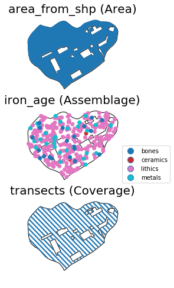

```python
from prospect.plotting import bb_plot
bb_plot(area_from_shp, iron_age_assemblage, coverage_transects, figsize=(10,8))
```

## Add building blocks to their respective `Survey` objects

```python
transect_survey.add_bb(bb=[area_from_shp, iron_age_assemblage, coverage_transects, leiap_team])
radial_survey.add_bb(bb=[area_from_shp, iron_age_assemblage, coverage_radials, leiap_team])
```

## Run the transect survey!!!

```python
%%timeit
transect_survey.run()
```

```
168 ms ± 4.53 ms per loop (mean ± std. dev. of 7 runs, 1 loop each)
```

## What happened?

With `Assemblage`

1. Extract `ideal_obs_rate` values (if distribution, select from it) -> `obs_rate`
2. Extract feature `time_penalty` values (if distribution, select from it) -> `time_penalty_obs`
3. Extract surface `vis` values (if distribution, select from it) -> `vis_obs`
   - TODO: if raster, extract value from raster

With `Coverage`

1. Extract `min_time_per_unit` (if distribution, select from it)
2. Calculate base_search_time (different methods for transect and radial) -> `base_search_time`
3. Allocate surveyors to survey units based on chosen assignment method
   - TODO: implement optimized methods
4. Merge data from `Team` to `Coverage`
5. Extract surveyor speed penalty values (if distribution, select from it) -> `speed_penalty_obs`

Find `Feature`s from `Assemblage` that intersect `Coverage` (via spatial join)

- Record which survey unit it intersects (or NaN)
- If intersects, set proximity to 1.0, else set proximity to 0.0 -> `proximity_obs`

Extract surveyor skill values (if distribution, select from it) -> `skill_obs`

`discovery_prob = obs_rate * vis_obs * proximity_obs * skill_obs`

## Inspect the results

```python
transect_survey.raw.head()
```

|  | feature_name | ideal_obs_rate | layer_name | shape | time_penalty | obs_rate | time_penalty_obs | vis_obs | index_right | coverage_name | ... | base_search_time | surveyor_name | skill | speed_penalty | surveyor_type | team_name | speed_penalty_obs | proximity_obs | skill_obs | discovery_prob |
| --- | --- | --- | --- | --- | --- | --- | --- | --- | --- | --- | --- | --- | --- | --- | --- | --- | --- | --- | --- | --- | --- |
| 0 | ceramics_0 | 1 | ceramics | POINT (533579.1230736007 4388848.757012193) | <scipy.stats._distn_infrastructure.rv_frozen o... | 1.0 | 29.911118 | 0.953721 | NaN | NaN | ... | NaN | NaN | NaN | NaN | NaN | NaN | NaN | 0.0 | NaN | NaN |
| 1 | ceramics_1 | 1 | ceramics | POINT (533638.8437563633 4388883.594077138) | <scipy.stats._distn_infrastructure.rv_frozen o... | 1.0 | 33.225566 | 0.983967 | NaN | NaN | ... | NaN | NaN | NaN | NaN | NaN | NaN | NaN | 0.0 | NaN | NaN |
| 2 | ceramics_2 | 1 | ceramics | POINT (533621.7017085332 4388842.121380774) | <scipy.stats._distn_infrastructure.rv_frozen o... | 1.0 | 42.691298 | 0.992431 | NaN | NaN | ... | NaN | NaN | NaN | NaN | NaN | NaN | NaN | 0.0 | NaN | NaN |
| 3 | ceramics_3 | 1 | ceramics | POINT (533701.8822548348 4388861.475305745) | <scipy.stats._distn_infrastructure.rv_frozen o... | 1.0 | 18.155546 | 0.904222 | NaN | NaN | ... | NaN | NaN | NaN | NaN | NaN | NaN | NaN | 0.0 | NaN | NaN |
| 4 | ceramics_4 | 1 | ceramics | POINT (533669.8100363142 4388763.046773043) | <scipy.stats._distn_infrastructure.rv_frozen o... | 1.0 | 26.759217 | 0.874576 | NaN | NaN | ... | NaN | NaN | NaN | NaN | NaN | NaN | NaN | 0.0 | NaN | NaN |

5 rows × 27 columns

```python
transect_survey.raw.shape
```

```
(345, 27)
```

```python
transect_survey.discovery.head()
```

|  | feature_name | shape | obs_rate | vis_obs | proximity_obs | skill_obs | discovery_prob |
| --- | --- | --- | --- | --- | --- | --- | --- |
| 0 | ceramics_0 | POINT (533579.1230736007 4388848.757012193) | 1.0 | 0.953721 | 0.0 | NaN | NaN |
| 1 | ceramics_1 | POINT (533638.8437563633 4388883.594077138) | 1.0 | 0.983967 | 0.0 | NaN | NaN |
| 2 | ceramics_2 | POINT (533621.7017085332 4388842.121380774) | 1.0 | 0.992431 | 0.0 | NaN | NaN |
| 3 | ceramics_3 | POINT (533701.8822548348 4388861.475305745) | 1.0 | 0.904222 | 0.0 | NaN | NaN |
| 4 | ceramics_4 | POINT (533669.8100363142 4388763.046773043) | 1.0 | 0.874576 | 0.0 | NaN | NaN |

```python
transect_survey.discovery.shape
```

```
(345, 7)
```

```python
transect_survey.discovery.describe()
```

|  | obs_rate | vis_obs | proximity_obs | skill_obs | discovery_prob |
| --- | --- | --- | --- | --- | --- |
| count | 345.000000 | 345.000000 | 345.000000 | 144.000000 | 144.000000 |
| mean | 0.953896 | 0.895474 | 0.417391 | 0.826899 | 0.712535 |
| std | 0.071549 | 0.093577 | 0.493845 | 0.124313 | 0.142363 |
| min | 0.568683 | 0.455100 | 0.000000 | 0.202242 | 0.196028 |
| 25% | 0.937874 | 0.852951 | 0.000000 | 0.750000 | 0.631235 |
| 50% | 0.982827 | 0.919738 | 0.000000 | 0.800000 | 0.701997 |
| 75% | 0.999331 | 0.963165 | 1.000000 | 0.900000 | 0.816730 |
| max | 1.000000 | 0.998340 | 1.000000 | 1.000000 | 0.985101 |

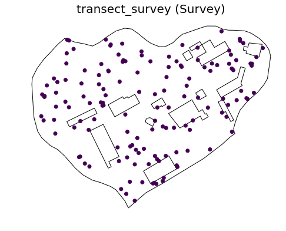

```python
transect_survey.discovery_plot()
```

## Run the radial survey!!!

```python
%%timeit
radial_survey.run()
```

```
199 ms ± 68.5 ms per loop (mean ± std. dev. of 7 runs, 1 loop each)
```

## Inspect the results

```python
radial_survey.discovery.head()
```

|  | feature_name | shape | obs_rate | vis_obs | proximity_obs | skill_obs | discovery_prob |
| --- | --- | --- | --- | --- | --- | --- | --- |
| 0 | ceramics_0 | POINT (533579.1230736007 4388848.757012193) | 1.0 | 0.978602 | 0.0 | NaN | NaN |
| 1 | ceramics_1 | POINT (533638.8437563633 4388883.594077138) | 1.0 | 0.889742 | 0.0 | NaN | NaN |
| 2 | ceramics_2 | POINT (533621.7017085332 4388842.121380774) | 1.0 | 0.849783 | 0.0 | NaN | NaN |
| 3 | ceramics_3 | POINT (533701.8822548348 4388861.475305745) | 1.0 | 0.994814 | 0.0 | NaN | NaN |
| 4 | ceramics_4 | POINT (533669.8100363142 4388763.046773043) | 1.0 | 0.622272 | 0.0 | NaN | NaN |

```python
radial_survey.discovery.shape
```

```
(345, 7)
```

```python
radial_survey.discovery.describe()
```

|  | obs_rate | vis_obs | proximity_obs | skill_obs | discovery_prob |
| --- | --- | --- | --- | --- | --- |
| count | 345.000000 | 345.000000 | 345.000000 | 43.000000 | 43.000000 |
| mean | 0.961975 | 0.900204 | 0.124638 | 0.814487 | 0.694775 |
| std | 0.054641 | 0.088285 | 0.330787 | 0.128558 | 0.117249 |
| min | 0.642895 | 0.486075 | 0.000000 | 0.472560 | 0.391651 |
| 25% | 0.946868 | 0.857338 | 0.000000 | 0.750000 | 0.617277 |
| 50% | 0.987322 | 0.919302 | 0.000000 | 0.800000 | 0.717824 |
| 75% | 0.999224 | 0.969791 | 0.000000 | 0.900000 | 0.772520 |
| max | 1.000000 | 0.999919 | 1.000000 | 1.000000 | 0.941859 |

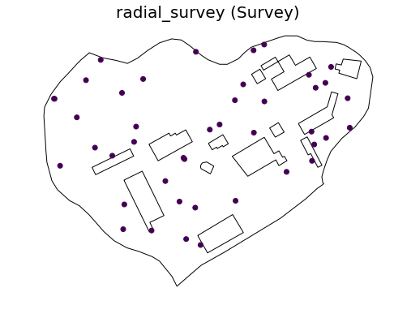

```python
radial_survey.discovery_plot()
```

## Set a discovery probability threshold and count the number of artifacts

```python
tdf = transect_survey.discovery
tdf.loc[tdf["discovery_prob"]>0.5, :].shape[0]
```

```
132
```

```python
rdf = radial_survey.discovery
rdf.loc[rdf["discovery_prob"]>0.5, :].shape[0]
```

```
41
```

## Compare area covered

```python
transect_survey.coverage.df.area.sum(), radial_survey.coverage.df.area.sum()
```

```
(12394.886855267505, 3874.9577445336463)
```

## Examine survey time

(converted to person-hours)

```python
transect_survey.total_time / 3600, radial_survey.total_time / 3600
```

```
(6.2078699281283, 1.1720055274409393)
```

```python
transect_survey.time_surveyunit.head()
```

|  | surveyunit_name | surveyor_name | base_search_time | sum_time_penalty_obs | speed_penalty_obs | total_time_per_surveyunit |
| --- | --- | --- | --- | --- | --- | --- |
| 0 | transects_1 | mid1 | 576.180770 | 247.235189 | 0.10 | 905.757555 |
| 1 | transects_10 | novice2 | 860.961970 | 271.421010 | 0.20 | 1358.859576 |
| 2 | transects_11 | novice3 | 841.372021 | 83.315743 | 0.25 | 1155.859704 |
| 3 | transects_12 | expert | 724.688780 | 329.052416 | 0.00 | 1053.741197 |
| 4 | transects_13 | mid1 | 761.063528 | 122.401285 | 0.10 | 971.811295 |

```python
transect_survey.time_surveyor
```

|  | surveyor_name | sum_base_search_time | sum_time_penalty_obs | speed_penalty_obs | total_time_per_surveyor |
| --- | --- | --- | --- | --- | --- |
| 0 | expert | 2206.781044 | 819.848403 | 0.00 | 3026.629447 |
| 1 | mid1 | 2597.510889 | 907.221359 | 0.10 | 3855.205473 |
| 2 | mid2 | 2742.676378 | 658.853478 | 0.10 | 3741.682842 |
| 3 | novice1 | 2908.692413 | 598.188483 | 0.20 | 4208.257076 |
| 4 | novice2 | 2490.716395 | 767.333053 | 0.20 | 3909.659338 |
| 5 | novice3 | 2339.943907 | 545.574145 | 0.25 | 3606.897566 |

```python
radial_survey.time_surveyunit.head()
```

|  | surveyunit_name | surveyor_name | base_search_time | sum_time_penalty_obs | speed_penalty_obs | total_time_per_surveyunit |
| --- | --- | --- | --- | --- | --- | --- |
| 0 | radials_10 | novice2 | 60 | 45.984534 | 0.2 | 127.181441 |
| 1 | radials_114 | expert | 60 | 24.162426 | 0.0 | 84.162426 |
| 2 | radials_116 | mid2 | 60 | 40.324209 | 0.1 | 110.356630 |
| 3 | radials_120 | expert | 60 | 40.712121 | 0.0 | 100.712121 |
| 4 | radials_13 | mid1 | 60 | 16.183245 | 0.1 | 83.801569 |

```python
radial_survey.time_surveyor
```

|  | surveyor_name | sum_base_search_time | sum_time_penalty_obs | speed_penalty_obs | total_time_per_surveyor |
| --- | --- | --- | --- | --- | --- |
| 0 | expert | 480 | 232.828301 | 0.00 | 712.828301 |
| 1 | mid1 | 420 | 229.267352 | 0.10 | 714.194087 |
| 2 | mid2 | 540 | 295.392927 | 0.10 | 918.932220 |
| 3 | novice1 | 300 | 170.274041 | 0.20 | 564.328850 |
| 4 | novice2 | 600 | 309.026266 | 0.20 | 1090.831520 |
| 5 | novice3 | 120 | 54.483937 | 0.25 | 218.104921 |

## Performance

```python
%%timeit
for i in range(100):
    transect_survey.run()
```

```
16.7 s ± 367 ms per loop (mean ± std. dev. of 7 runs, 1 loop each)
```

```python
import datetime
print(str(datetime.datetime.now()))

for i in range(1000):
    transect_survey.run()

print(str(datetime.datetime.now()))
```

```
2019-04-26 01:10:08.119562
2019-04-26 01:12:55.056036
```